# Lab02

Janish Parikh

12/08/2020

#Question-01 Central limit theorem: (A) Generate mean subtracted X1, X2, …, XN uniformly distributed, i.e., U[0, 1], IID random variables. Generate at least 10000 samples for each of the random variables and let N = 25.

```r
set.seed(1)
N<-25
randomvariables<-matrix(data=rep(0,25000), nrow = 10000, ncol = N)
for (i in c(1:N)){
  randomvariables[,i] <-runif(10000, 0, 1)
  randomvariables[,i]<-randomvariables[,i]-mean(randomvariables[,i])
}
colnames(randomvariables)<-c("X1","X2","X3","X4",'X5',"X6","X7",'X8',"X9","X10",
                             "X11","X12","X13",'X14',"X15","X16","X17",
                             "X18",'X19',"X20","X21","X22","X23","X24","X25")
samplespace<-tbl_df(data=randomvariables)
head(samplespace)
```

```
## # A tibble: 6 x 25
##        X1     X2      X3      X4      X5      X6     X7      X8      X9    X10
##     <dbl>  <dbl>   <dbl>   <dbl>   <dbl>   <dbl>  <dbl>   <dbl>   <dbl>  <dbl>
## 1 -0.235  -0.435 -0.285  -0.0857  0.0888  0.0776  0.231  0.259  -0.0851  0.207
## 2 -0.128   0.176 -0.381  -0.360   0.0487  0.200   0.147  0.259  -0.195  -0.288
## 3  0.0727  0.235 -0.350  -0.0435  0.0925 -0.163   0.314 -0.377   0.140   0.398
## 4  0.408  -0.389 -0.186   0.302  -0.112  -0.381  -0.396 -0.302   0.205   0.354
## 5 -0.298  -0.454 -0.346  -0.180  -0.244   0.377  -0.166  0.0691  0.0662 -0.237
## 6  0.398  -0.369  0.0309  0.367   0.236  -0.449  -0.101  0.0121  0.297  -0.370
## # ... with 15 more variables: X11 <dbl>, X12 <dbl>, X13 <dbl>, X14 <dbl>,
## #   X15 <dbl>, X16 <dbl>, X17 <dbl>, X18 <dbl>, X19 <dbl>, X20 <dbl>,
## #   X21 <dbl>, X22 <dbl>, X23 <dbl>, X24 <dbl>, X25 <dbl>
```

starting from X1 start adding the random variables, i.e.,

Compute Yk= sum(Xi….Xk) Plot the PDFs for each of the Yk.

```r
plot_histogram<-function(x){
  p<-ggplot(data=data.frame(data=x),aes(x=data))+
    geom_histogram(aes(y=stat(ndensity)),bins=10)+
    geom_density(aes(y=stat(scaled)),fill = "red",alpha = 0.1)
  plot(p)
}
```

```
## Note: Using an external vector in selections is ambiguous.
## i Use `all_of(i)` instead of `i` to silence this message.
## i See <https://tidyselect.r-lib.org/reference/faq-external-vector.html>.
```

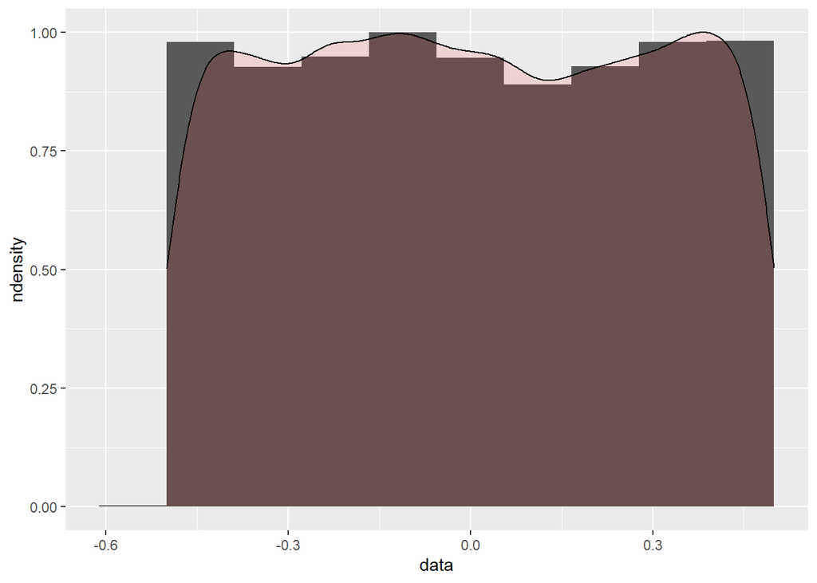

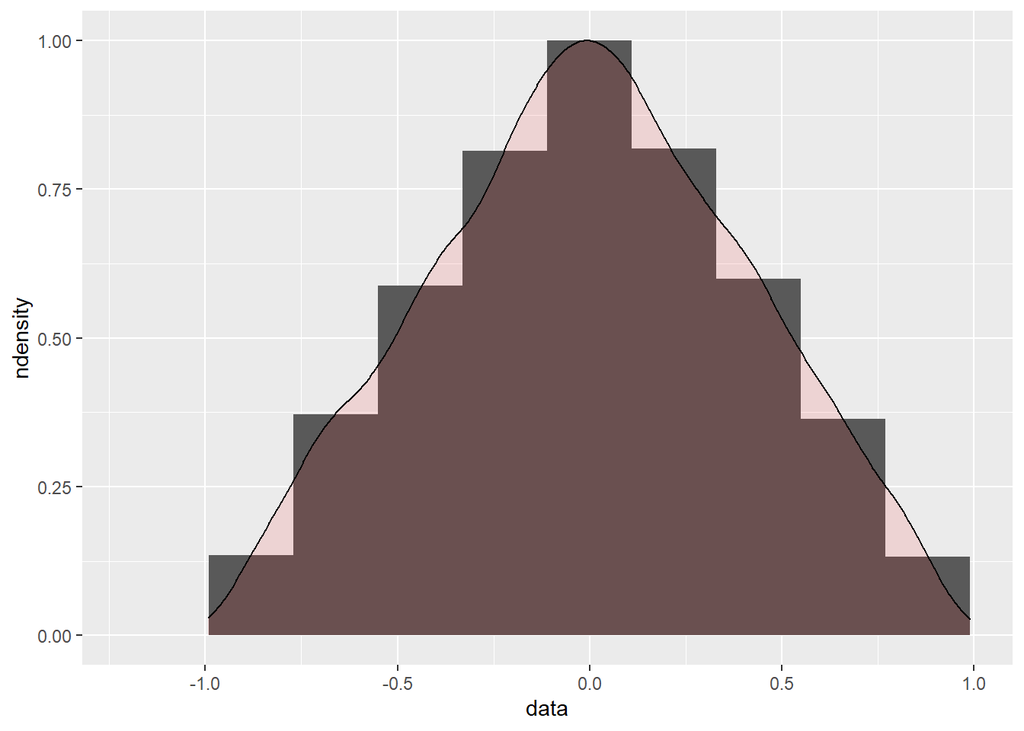

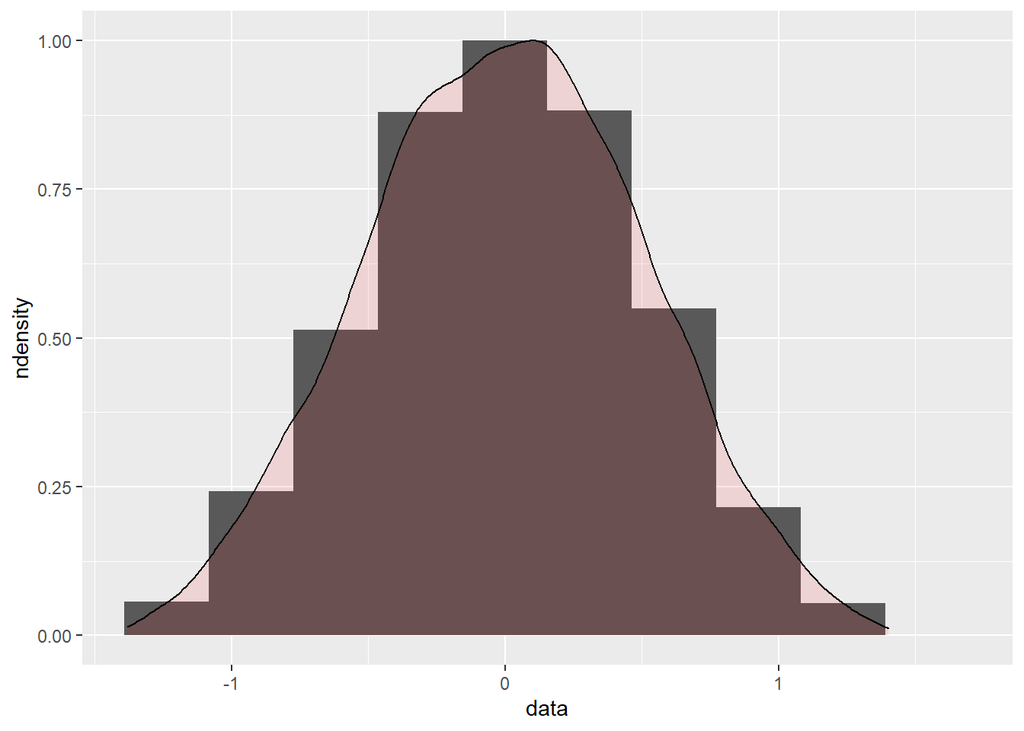

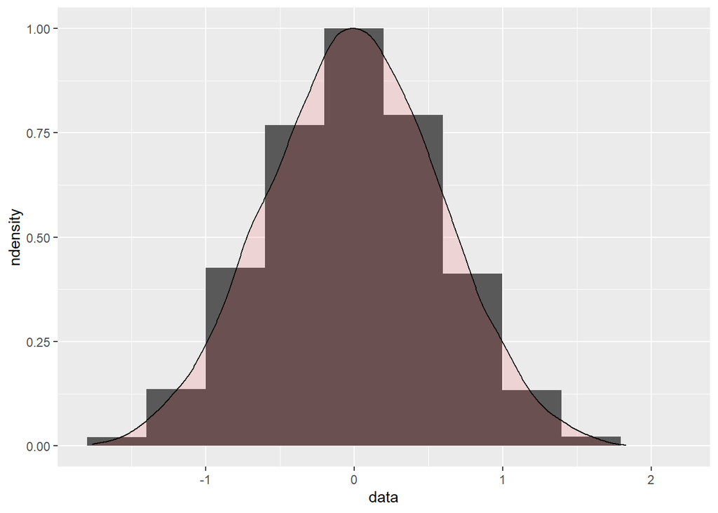

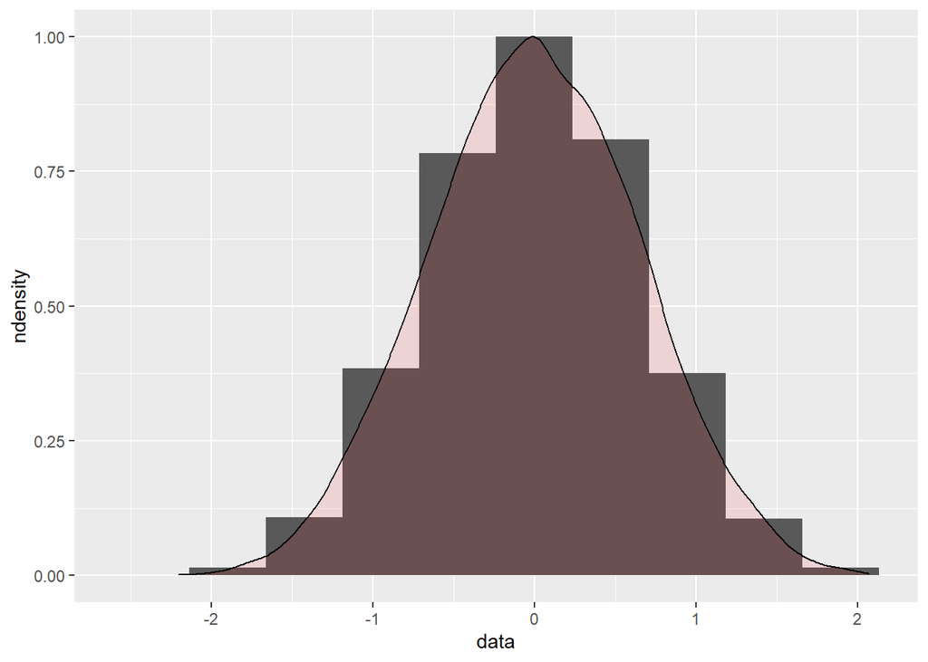

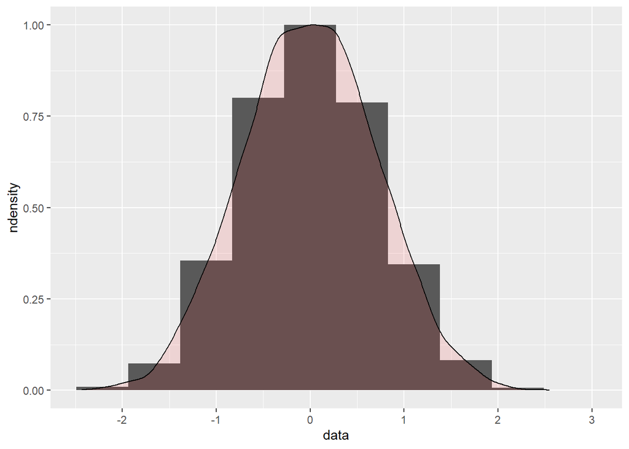

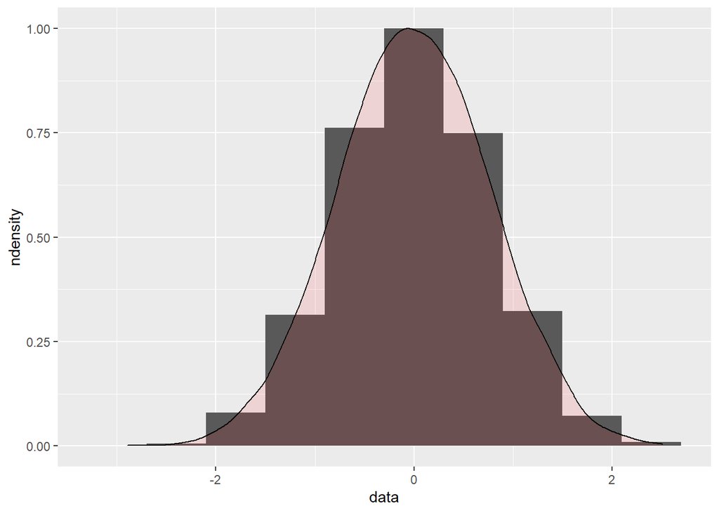

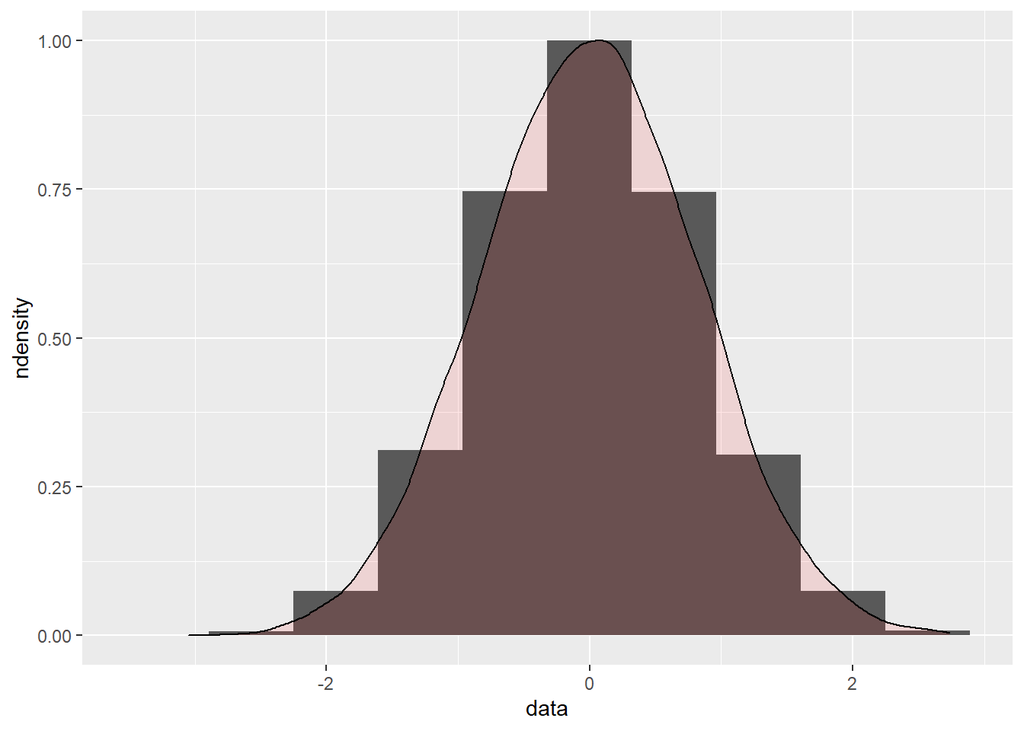

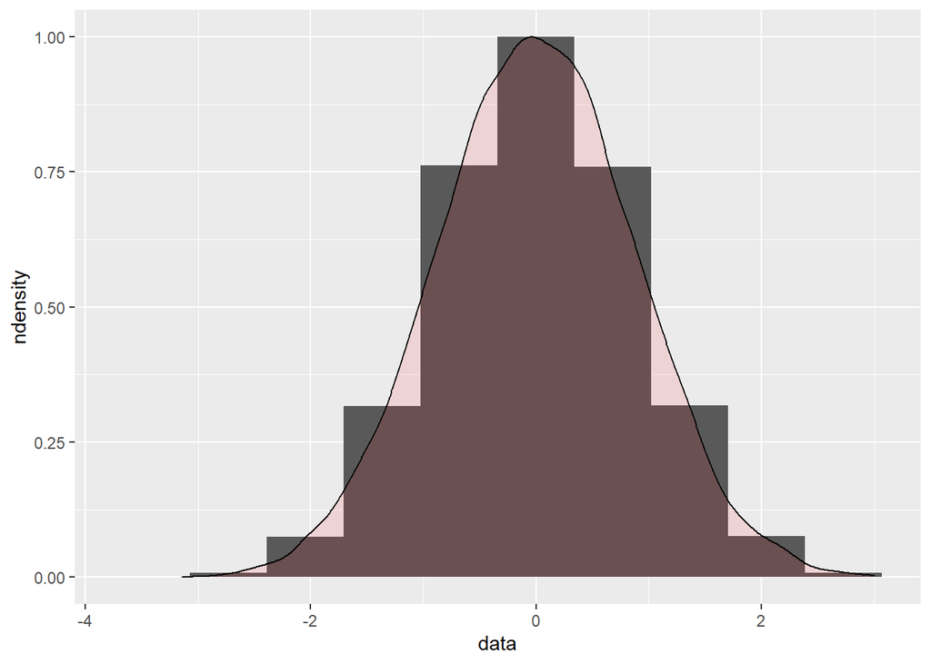

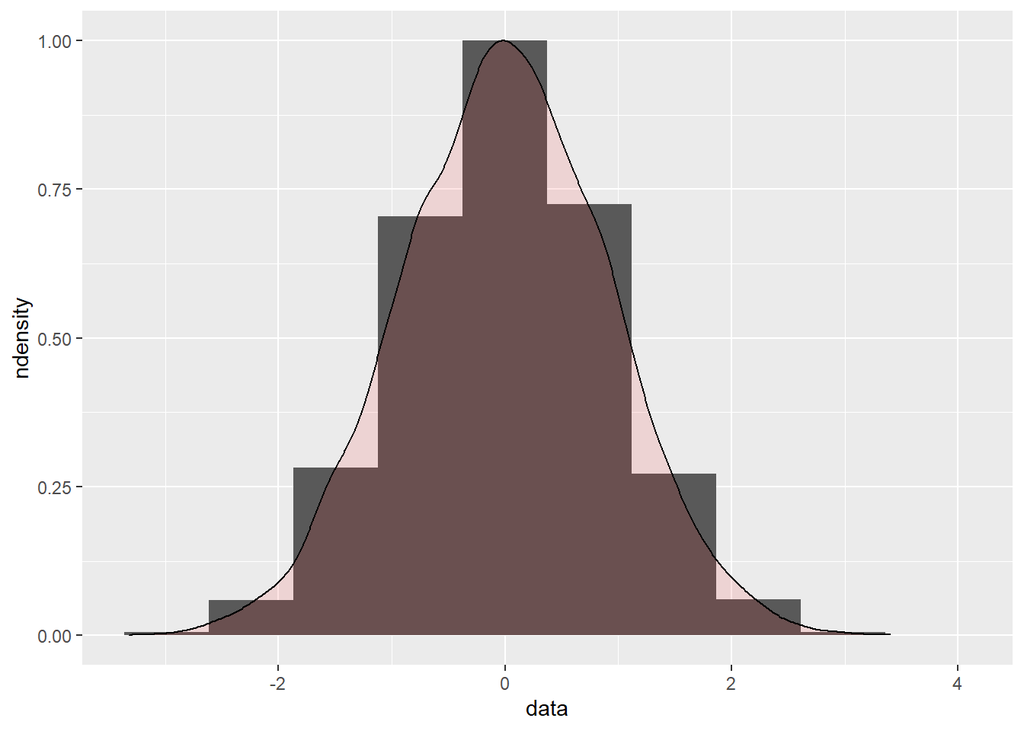

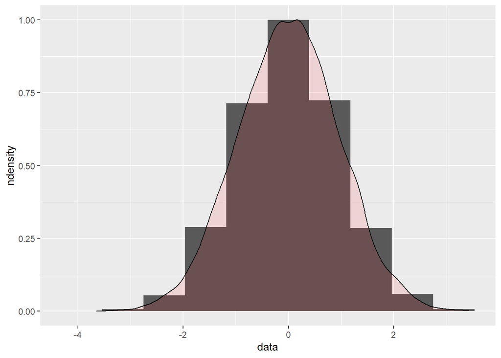

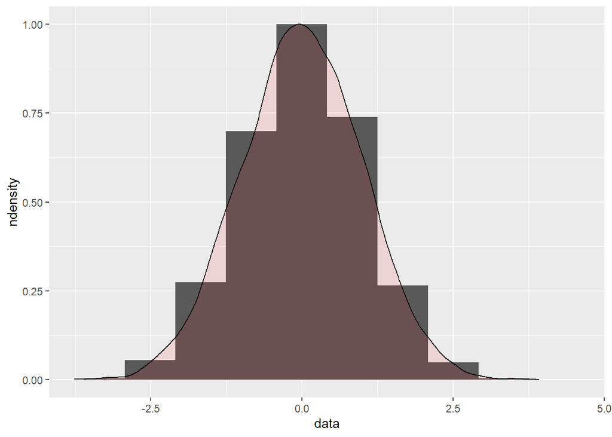

[13 more figures not shown]

```r
pdf<-function(samplespace,ytable, N =25){
ytable<-samplespace
colnames(ytable)<-gsub("X","Y",colnames(samplespace))
for (i in c(1:N)){
  s1<-select(samplespace,c(1:i))
  ytable[,i]<-rowSums(s1)
}
head(ytable)
x<-list(ytable)
 list<-sapply(x[[1]], plot_histogram)}
pdf(samplespace)
```

2. Repeat the above experiment for mean subtracted independent random variables, with different distributions, e.g., Uniform, Laplacian, etc.

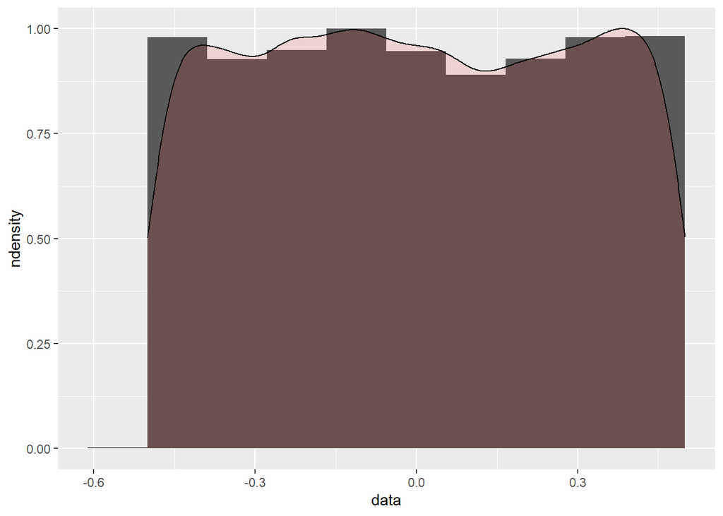

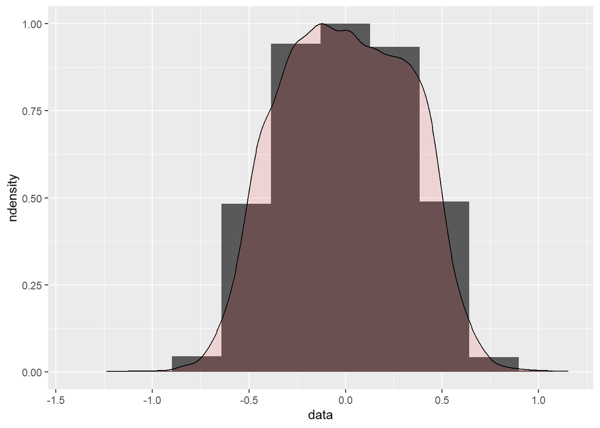

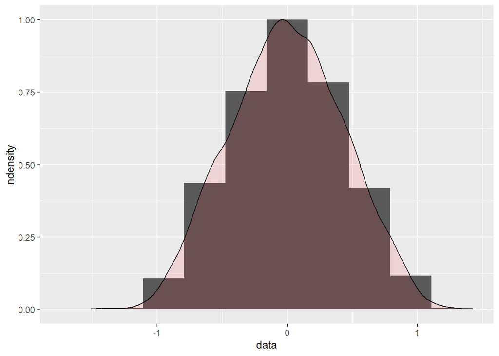

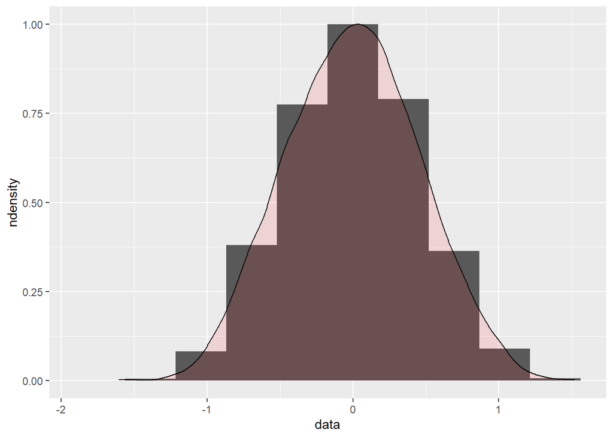

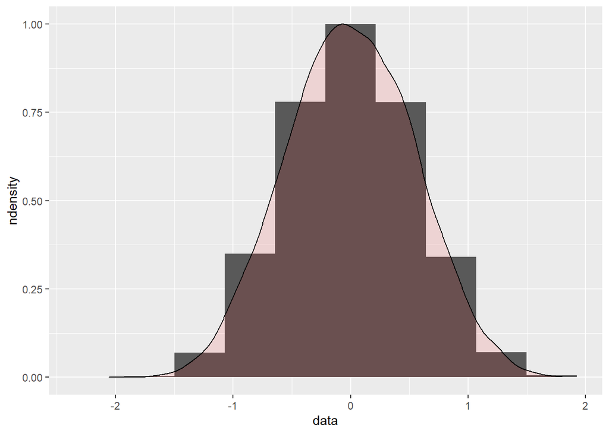

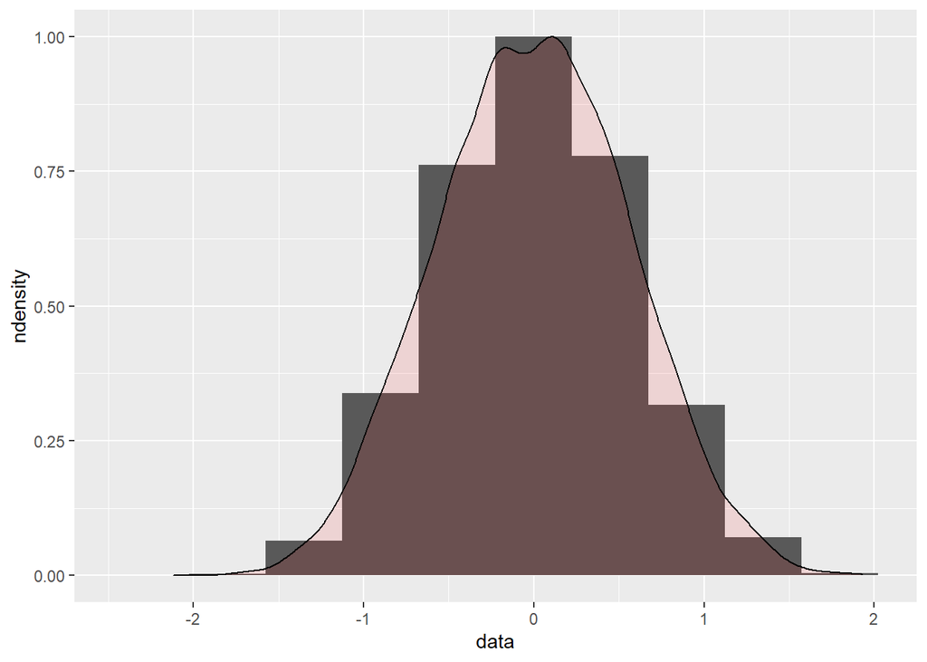

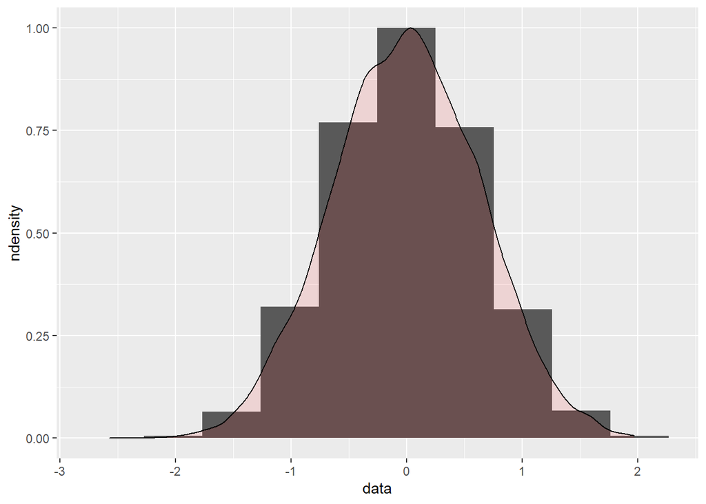

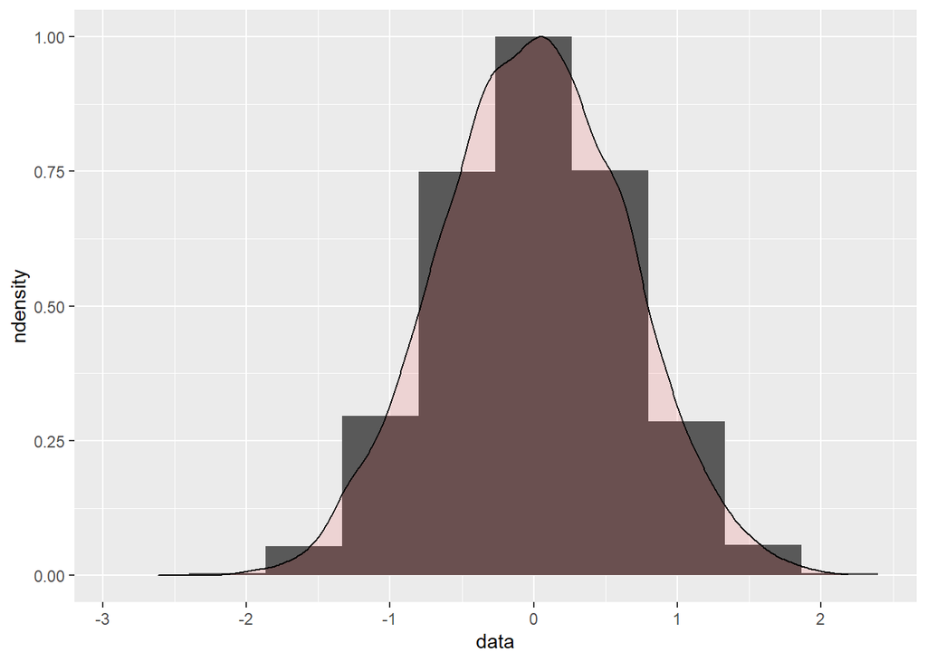

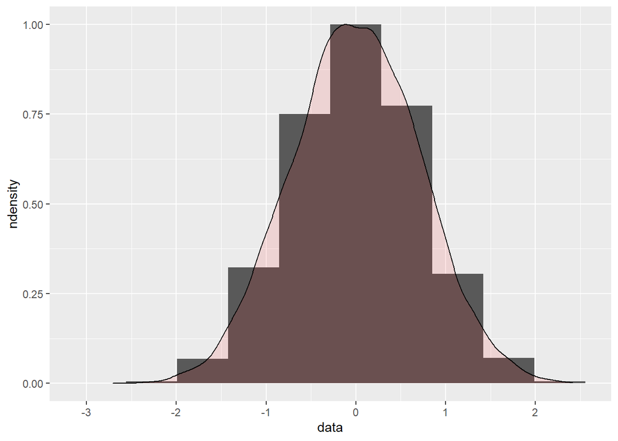

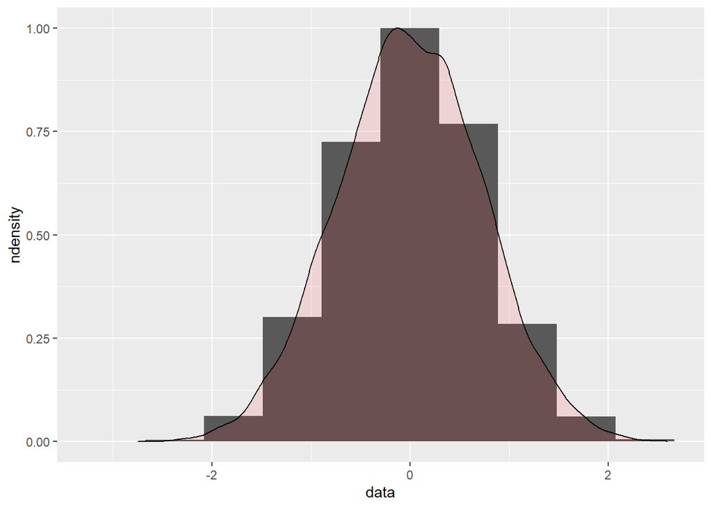

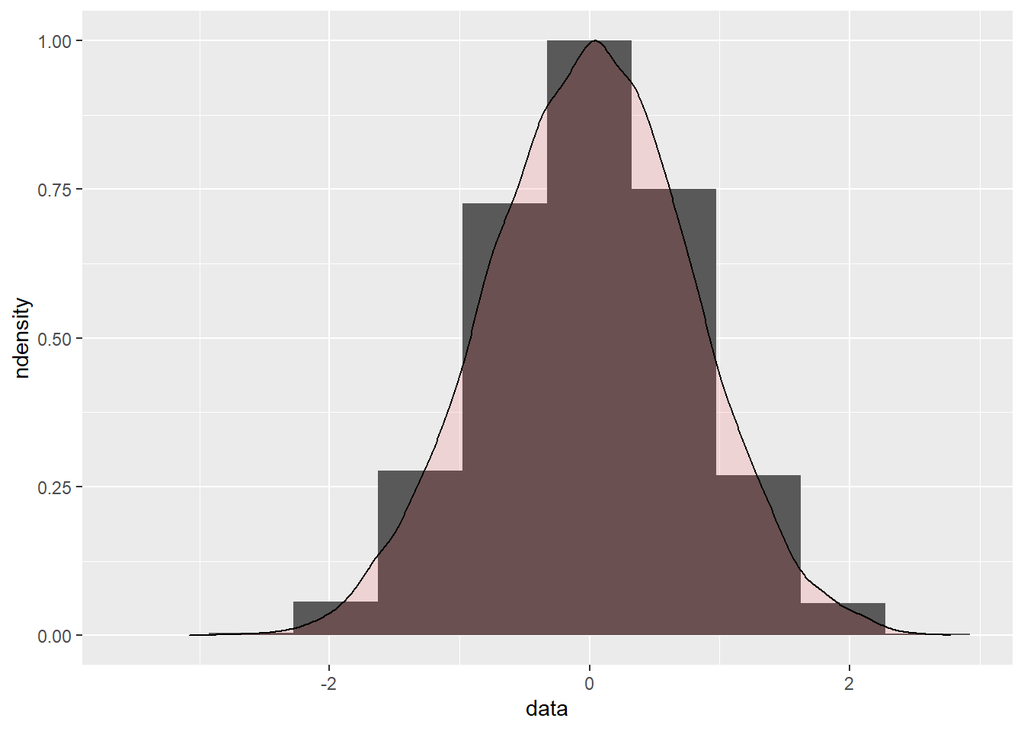

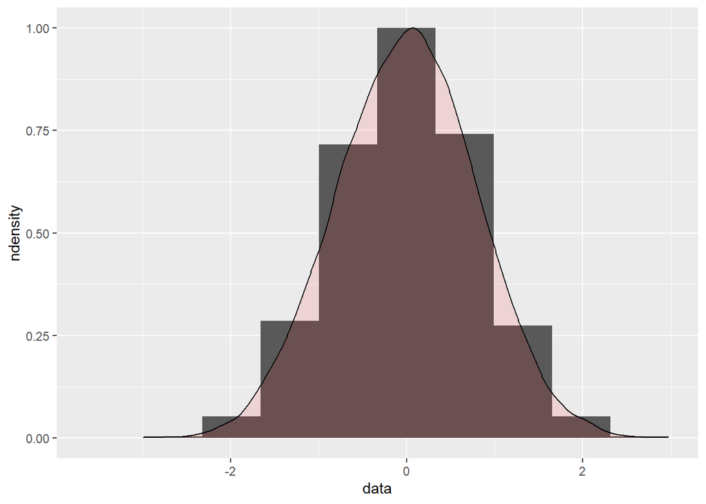

[13 more figures not shown]

```r
set.seed(1)
for (i in c(1:N)){
  if(i%%2==0){
  randomvariables[,i] <-rlaplace(10000, 0.5, 0.1)
  } else{
    randomvariables[,i]<-runif(10000,0,1)
  }
  randomvariables[,i]<-randomvariables[,i]-mean(randomvariables[,i])
}
samplespacemixed<-tbl_df(data=randomvariables)

pdf(samplespacemixed,ytable = ytablemixed)
```